[figure not shown]

LI-41

Front Fog Light Assembly

LIGHTING SYSTEM

22.Front Fog Light Assembly

A: REMOVAL

1) Disconnect the ground cable from battery. <Ref. to NT-5, BATTERY, NOTE, Note.>

NOTE:

For models other than STI model, disconnect the ground terminal from battery sensor.

2) Lift up the vehicle.

3) Remove the screw and clips, and turn over the mud guard - front.

4) Remove the fog light assembly - front.

(1) Disconnect the connector.

(2) Remove the screws and guide, and remove the fog light assembly - front.

LI-01721

LI-01739

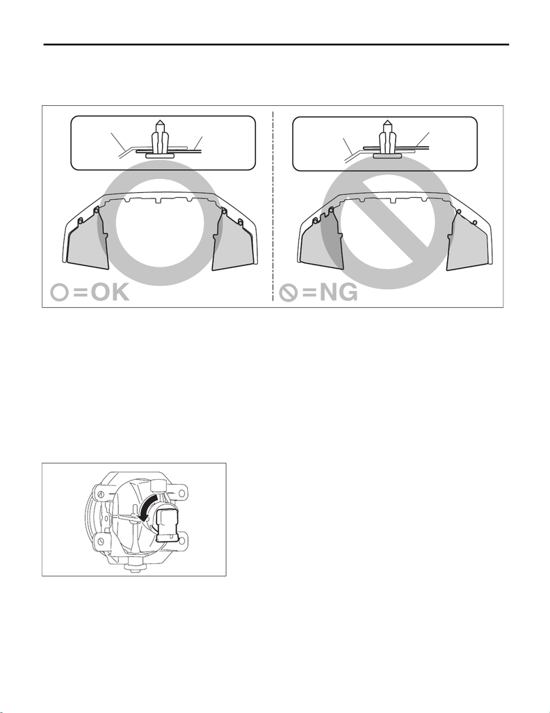

LI-42

Front Fog Light Assembly

LIGHTING SYSTEM

B: INSTALLATION

CAUTION:

Install the mud guard - front so that the front end of the mud guard (b) comes outside the bumper face -

front (a).

1) Install the fog light assembly - front.

2) Install the mud guard - front.

3) Lower the vehicle.

4) Connect the battery ground terminal. <Ref. to NT-5, BATTERY, NOTE, Note.>

NOTE:

For models other than STI model, connect the ground terminal to battery sensor.

5) Adjust the fog light beam. <Ref. to LI-43, FOG LIGHT AIMING, ADJUSTMENT, Front Fog Light Assem-

bly.>

C: DISASSEMBLY

CAUTION:

Use a dry clean cloth so that no grease or water adheres to the glass portion of the bulb.

Rotate in the direction of arrow shown in the figure to remove the front fog light bulb.

D: ASSEMBLY

CAUTION:

Use a dry clean cloth so that no grease or water adheres to the glass portion of the bulb.

Install the front fog light bulb.

COM00136

(a)

(b)

(a)

(b)

LI-01740

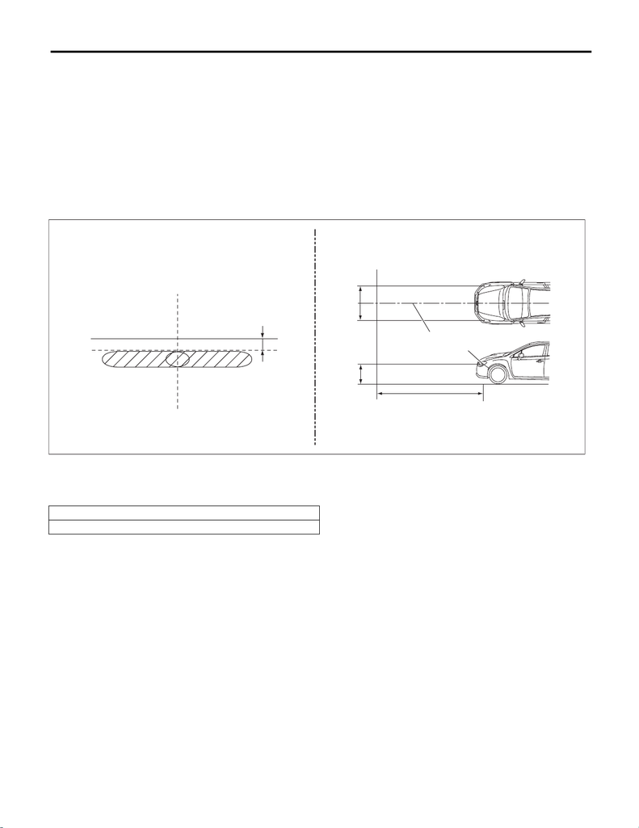

LI-43

Front Fog Light Assembly

LIGHTING SYSTEM

E: ADJUSTMENT

1. FOG LIGHT AIMING

1) Before checking the fog light beam level, be sure of the following:

• The area around the fog light has not sustained any accident, damage or other type of deformation.

• The vehicle is parked on a level surface.

• The inflation pressure of tires is correct.

• The vehicle does not have load.

• Vehicle’s fuel tank is fully filled.

2) Bounce the vehicle several times to normalize the suspension.

3) Make certain that someone is seated in the driver’s seat.

4) Place the vehicle with the front end facing to the measurement panel.

(A) Vehicle center (C) 3 m (10 ft) (D) Height of fog light center

(B) Bulb center marking

h mm (in) at 3 m (10 ft)

40 (1.58)

LI-01741

(A)

h

(D)

W

W2

W1

(A)

(C)

(B)

(D)

[figure not shown]

LI-44

Front Fog Light Assembly

LIGHTING SYSTEM

5) Adjust the fog light beam.

(1) Remove the clips, and turn over the mud guard - front.

(2) Adjust the beam level by turning the aiming screw.

LI-01724

LI-01742

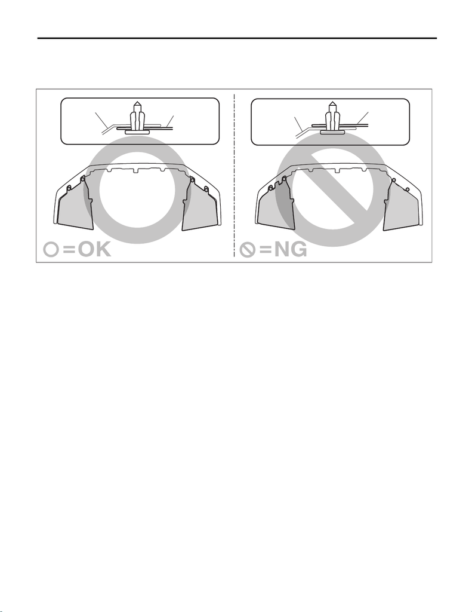

LI-45

Front Fog Light Assembly

LIGHTING SYSTEM

(3) Install the mud guard - front.

CAUTION:

Install the mud guard - front so that the front end of the mud guard (b) comes outside the bumper

face - front (a).

COM00136

(a)

(b)

(a)

(b)